# Linear models: Interpretation

> In this session, we will be exploring some of the key assumptions of the linear model (OLS) that – if violated – would vouch for a generalized linear model approach (GLM).

Two weeks ago, I claimed that OLS assumes a dependent variable that is continuous and unbounded. This week, I will tell you why this is a big, fat lie: It suffices that the residuals i) follow a normal distribution and ii) that they have constant variance (homoscetastic).

The data we will be working with are the replication data for [Blurred Lines betwen electoral and parliamentary representation: The use of constituency staff among Members of the European Parliament](https://journals.sagepub.com/doi/pdf/10.1177/14651165221149900) *European Union Politics* (2023). The main argument in the article is that MEPs are (re-)election seekers and will use their parliamentary allowances to maximize their chance of reelection. In particular, we expect that MEPs will increase their investmen in their local presence (constituency work) before elections and when they stand to win by cultivating a personal vote.

I start by fetching the R packages we will use from the library.

```r
library(dplyr); library(ggplot2)
```

# Explore the data

To approximate MEPs’ local investment, we measure the number of local/constituency assistants that Members of the European Parliament hire.

We begin by loading in the data.

If I have an internet connection, I can download the file directly from the class’ website and put it in my working directory.

```r
download.file(url = "https://siljehermansen.github.io/teaching/beyond-linear-models/MEP2014.rda",
              destfile = "MEP.rda")
```

Now, I can load it into R and rename the object to my liking (`df`).

```r
#Load in
load("MEP2014.rda")

#Rename
df <- MEP2014
```

## Univariate distribution

Our dependent variable, “LocalAssistants”, is a count of the number of local employees (constituency staff) an MEP has. Since MEPs can share assistants, the variable also reports fractions.

I begin by exploring the univariate distribution.

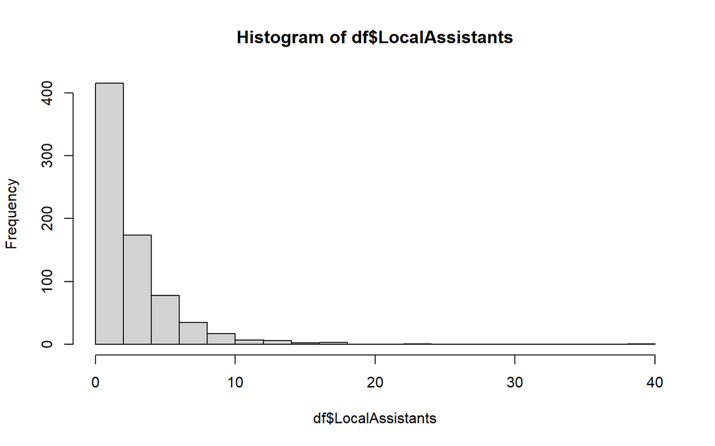

```r
hist(df$LocalAssistants,
     breaks = 20)
```

There are a lot of MEPs with only a few local assistants, some MEPs have many local employees, while none has a negative number of MEPs.

## Bivariate statistics

The article makes the claim that MEPs elected from candidate-centred electoral systems are more likely to invest locally, since theyneed the name recognition. The variable “OpenList” is a binary indicator of whether an MEP is elected from such a system.

A natural start of an analysis is to compare the average number of local hires in each group. The `group_by()` function from `dplyr` is useful for this.

```r
df %>%
  group_by("Candidate-centred" = OpenList) %>%
  summarize("Average number" = mean(LocalAssistants))
```

| Candidate-centred | Average number |
| --- | --- |
| 0 | 2.468031 |
| 1 | 3.416667 |

Ok. There is a difference between the two groups, but is it significant?

One way to test if two groups are different, is to perform a t-test. However, we can also use linear models for this. That’s the point Gelman and Hill make. When we run an OLS with categorical predictors, we can interpret the coefficients as predicted averages for each group.

The function for linear models in R is `lm()`.

```r
mod <- lm(LocalAssistants ~ OpenList,
          data = df)
```

Let’s see if we can recognize the results.

```r
summary(mod)
```

```
##
## Call:
## lm(formula = LocalAssistants ~ OpenList, data = df)
##
## Residuals:
##    Min     1Q Median     3Q    Max
## -3.417 -2.417 -0.468  1.532 36.083
##
## Coefficients:
##             Estimate Std. Error t value Pr(>|t|)
## (Intercept)   2.4680     0.1608  15.351  < 2e-16 ***
## OpenList      0.9486     0.2343   4.049 5.68e-05 ***
## ---
## Signif. codes:  0 '***' 0.001 '**' 0.01 '*' 0.05 '.' 0.1 ' ' 1
##
## Residual standard error: 3.179 on 737 degrees of freedom
## Multiple R-squared:  0.02176,    Adjusted R-squared:  0.02044
## F-statistic:  16.4 on 1 and 737 DF,  p-value: 5.684e-05
```

#### Your turn

- can you calculate the predicted number of local assistants for OpenList == 0?
- can you calculate the predicted number of local assistants for OpenList == 1?
- What is the meaning of the $\beta$ coefficient here?

We could ask R to predict the y-values for us, given the data we have, the info contained in the predictors (OpenList) and the coefficients from the model. This is what we’d call “in-sample” predictions.

```r
#Predict
MEP$predicted <- predict(mod,
                         #The data we used for estimation
                         newdata = MEP)

#Distribution of predicted values
table(MEP$predicted)
```

[output not shown]

There are two ways of interpreting the regression coefficients:

- we can use the OLS to compare means $\rightarrow$ *the following OLS assumptions don’t matter*
- we can use it to make inferences: one unit increase in $x$ is a $\beta$ increase in $y$. $\rightarrow$ *the following OLS assumptions do matter*

# Multivariate regression

There are many potential confounders in this analysis. In particular, MEPs come from different EU member states. They have the same budget for parliamentary assistance, but their local assistants are hired on local wages. It means that Danish MEPs can hire fewer assistants than Polish MEPs.

```r
mod2 <- lm(LocalAssistants ~
             OpenList +
             LaborCost,
           df)
```

```r
summary(mod2)
```

```
##
## Call:
## lm(formula = LocalAssistants ~ OpenList + LaborCost, data = df)
##
## Residuals:
##    Min     1Q Median     3Q    Max
## -4.492 -1.938 -0.414  1.078 35.001
##
## Coefficients:
##             Estimate Std. Error t value Pr(>|t|)
## (Intercept)  4.12659    0.28612  14.422  < 2e-16 ***
## OpenList     0.82883    0.22784   3.638 0.000294 ***
## LaborCost   -0.07020    0.01015  -6.913 1.03e-11 ***
## ---
## Signif. codes:  0 '***' 0.001 '**' 0.01 '*' 0.05 '.' 0.1 ' ' 1
##
## Residual standard error: 3.083 on 736 degrees of freedom
## Multiple R-squared:  0.08141,    Adjusted R-squared:  0.07891
## F-statistic: 32.61 on 2 and 736 DF,  p-value: 2.689e-14
```

# Present your results: table of results

There are several ways to create result tables. You can always export coefficients and standard errors to Excel via `write.table()`, but there are easier solutions.

The package `stargazer` gives you a nice, pre-made presentation of most model objects (with significance stars).

We start by loading the package. It has one function to take note of, namely: `stargazer()`.

```r
library(stargazer)
```

By default, stargazer will give you LaTeX code in the output. Do you want to see the result in R? Use type = “text”. `

```r
stargazer(mod,
          type = "text")
```

```
##
## ===============================================
##                         Dependent variable:
##                     ---------------------------
##                           LocalAssistants
## -----------------------------------------------
## OpenList                     0.949***
##                               (0.234)
##
## Constant                     2.468***
##                               (0.161)
##
## -----------------------------------------------
## Observations                    739
## R2                             0.022
## Adjusted R2                    0.020
## Residual Std. Error      3.179 (df = 737)
## F Statistic           16.396*** (df = 1; 737)
## ===============================================
## Note:               *p<0.1; **p<0.05; ***p<0.01
```

Multiple models You can present multiple models in stargazer at the same time. Just add all the model objects first in the function. Then you get one column per model.

```r
stargazer(mod, mod2,
          type = "text")
```

```
##
## ===================================================================
##                                   Dependent variable:
##                     -----------------------------------------------
##                                     LocalAssistants
##                               (1)                     (2)
## -------------------------------------------------------------------
## OpenList                   0.949***                0.829***
##                             (0.234)                 (0.228)
##
## LaborCost                                          -0.070***
##                                                     (0.010)
##
## Constant                   2.468***                4.127***
##                             (0.161)                 (0.286)
##
## -------------------------------------------------------------------
## Observations                  739                     739
## R2                           0.022                   0.081
## Adjusted R2                  0.020                   0.079
## Residual Std. Error    3.179 (df = 737)        3.083 (df = 736)
## F Statistic         16.396*** (df = 1; 737) 32.612*** (df = 2; 736)
## ===================================================================
## Note:                                   *p<0.1; **p<0.05; ***p<0.01
```

Now it’s easier to compare the models. Among other things, we get an idea of what happens when we add controls.

Here we see that the effect of electoral system is moderated when we take into account the differences in labor cost.

**Pimp your table** Stargazer also has many additional arguments that allow us to customize the appearance. Some of these are especially interesting if you want to customize the table for a Danish audience.

```r
additional_arguments <- c("type =",
                          "title = ",
                          "covariate.labels = ",
                          "dep.var.labels =",
                          "dep.var.caption =",
                          "decimal.mark = ")
alternatives <- c("'text', 'html', 'tex'",
                  "'My Title'",
                  "c('var 1', 'var 2')",
                  "A text, or a vector with text",
                  "'Dependent variable'",
                  "',', '.' etc.")
operation <- c("What file type is this?",
               "Add a title",
               "Vector with variable names",
               "What is my dependent variable called?",
               "Title for dependent variable",
               "What decimal separator do I use? (e.g., ',')")

tab_stargazer <- cbind(additional_arguments,
                       alternatives,
                       operation)
colnames(tab_stargazer) <- c("Argument",
                             "Alternatives",
                             "What it does")
```

Results table in stargazer: additional arguents

| Argument | Alternatives | What it does |
| --- | --- | --- |
| type = | ‘text’, ‘html’, ‘tex’ | What file type is this? |
| title = | ‘My Title’ | Add a title |
| covariate.labels = | c(‘var 1’, ‘var 2’) | Vector with variable names |
| dep.var.labels = | A text, or a vector with text | What is my dependent variable called? |
| dep.var.caption = | ‘Dependent variable’ | Title for dependent variable |
| decimal.mark = | ‘,’, ‘.’ etc. | What decimal separator do I use? (e.g., ‘,’) |

### Export the table

Do you want the result in HTML (for export to Word), change it to “html” and print the table in a separate file.

```r
stargazer(mod,
          type = "html",
          out = "result_table.html")
```

|  | *Dependent variable:* |
| --- | --- |
|  | LocalAssistants |
| OpenList | 0.949*** |
|  | (0.234) |
| Constant | 2.468*** |
|  | (0.161) |
| Observations | 739 |
| R<sup>2</sup> | 0.022 |
| Adjusted R<sup>2</sup> | 0.020 |
| Residual Std. Error | 3.179 (df = 737) |
| F Statistic | 16.396*** (df = 1; 737) |
| *Note:* | p<0.1; p<0.05; p<0.01 |

Open the file in your web browser and copy-paste it into Word.

# Interpretation

Let’s interpret the results using inference. We can either focus on the *relative* change in local staff, or the *absolute* size of the local staff.

### Marginal effect

We can interpret the results as a relative increase in $y$ when $x$ increases with one unit.

Here, we might say that MEPs from candidate-centered systems (`OpenList == 1`) have on average a local staff containing 0.9 more assistants than MEPs from party centered systems (`OpenList == 0`). Note how we interpret the units: $\beta$ reports the increase in *local assistants* ($y$) when $x$ increases by one unit.

*Be realistic* When we make interpretations, we should make sure that the increase we imagine for $x$ is a realistic change in the variable. Depending on what we are interested in, we might consider realistic differences between observations (e.g. between different MEPs), or realistic changes/elasticity in $x$ (e.g. a realistic increase in hires for one MEP). To make that assessment, you need to know the descriptive statistics (univariate distributions) of your predictors.

Here I make a table of descriptive statistics using stargazer. It creates the summary statistics automatically when we feed it with a data frame.

I begin by selecting my variables from the data using `dplyr`.

```r
df0 <- df %>% select(LocalAssistants,
                     OpenList,
                                   LaborCost,
                                   position,
                                   SizeNatPal,
                                   cabinet_party)
```

I then make the table. Here, I use additional arguments to specify what kind of statistics I want. Use the `?stargazer` command to get tips.

**Descriptive statistics**

| Statistic | N | Mean | St. Dev. | Min | Pctl(25) | Median | Pctl(75) | Max |
| --- | --- | --- | --- | --- | --- | --- | --- | --- |
| LocalAssistants | 739 | 2.915 | 3.212 | 0.000 | 1.000 | 2.000 | 4.000 | 39.500 |
| OpenList | 739 | 0.471 | 0.499 | 0 | 0 | 0 | 1 | 1 |
| LaborCost | 739 | 22.824 | 11.207 | 3.800 | 9.700 | 25.800 | 31.400 | 40.600 |
| position | 664 | 5.174 | 1.594 | 1.000 | 4.545 | 6.000 | 6.273 | 7.000 |
| SizeNatPal | 722 | 407.717 | 202.729 | 56 | 199.2 | 412 | 630 | 650 |
| cabinet_party | 739 | 0.428 | 0.495 | 0 | 0 | 0 | 1 | 1 |

#### Your turn:

- Can you make an interpretation of the effect of labor cost on MEPs’ local staff?

### Predicted values using scenarios

We can interpret the results as a comparison of **predicted values** when the value of “OpenList” increases by one unit.

To calculate the predicted values of model 1, we fill in the linear equation:

> $y_i = \alpha + \beta \times x_i$

R gives us the coefficients, we provide the data. This data is artificial, they are “scenarios” that we create. That is, we “invent” data points. The procedure looks something like this. Here I’ve created two scenarios for $x_1$ and $x_2$.

| scenario | y | $\alpha$ | $\beta$ | x |  |
| --- | --- | --- | --- | --- | --- |
| Party-centered | 2.4680307 | 2.4680307 | 0.948636 | 0 |  |
| Candidate-centered | 3.4166667 | 2.4680307 | 0.948636 | 1 |  |

We can do this in R. The work process is as follows:

1. **Create a dataset with hypothetical scenarios:** This means creating a dataset where all variables have a probable/typical value. Then let the variable you want to illustrate the effect of vary.
2. **Predict y.** Insert the predicted y-values into the hypothetical dataset.
3. **Interpret** Here, the interpretation focuses on the predicted value of the dependent variable.
   1. *Numbers* what are the different predicted values?
   2. *Text* Compare single scenarios and make use of plain English. E.g. what is the difference between two predicted $y$s?
   3. *Plot the results.* The choice of graphics depends on the measurement level of the variable you want to illustrate. The effect of a categorical/binary variable can be best illustrated with a **coefficient plot**, while an **effect plot** (a line) is best for continuous variables.

### Create the data for the scenaros

I begin by making a data frame. Be aware that you will have to make data for the intercept too.

```r
newdata <- data.frame(
  Intercept = 1,
  OpenList = c(0,1))
newdata
```

| Intercept | OpenList |
| --- | --- |
| 1 | 0 |
| 1 | 1 |

Now, I can predict the y values by multiplying the regression coefficients with the data. We can use matrix manipulation.

```r
#A vector of coefficients
coefs <- coefficients(mod)
```

Now, I can multiply. To that, I have to “flip” (transpose) the matrix, so that the first coefficient in my vector is multiplied with the first column in my data etc.

```r
preds <- coefs %*% t(newdata)
preds
```

```
##          [,1]     [,2]
## [1,] 2.468031 3.416667
```

1. Numeric interpretation

The predicted value for scenario 1 is 2.4680307, and the predicted value for scenario 2 is 3.4166667.

2. Plain English interpretation.
3. Plot it.

Start by making a data set for interpretation. We will also use it for graphical display, just as we did before.

```r
#Make a vector out of your predicted values
preds <- as.vector(preds)

#Add it to your newdata object (and rename it)
dfp <- cbind(newdata,
             "Staff size" = preds)

dfp
```

| Intercept | OpenList | Staff size |
| --- | --- | --- |
| 1 | 0 | 2.468031 |
| 1 | 1 | 3.416667 |

The table is useful for your numeric and english interpretations. It is also useful for graphical display.

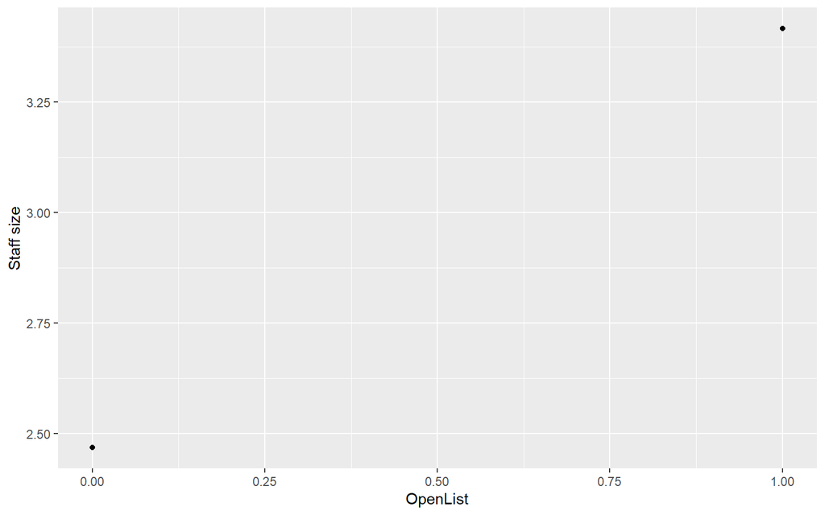

```r
ggplot(dfp) +
  geom_point(aes(x = OpenList,
                 y = `Staff size`))
```

These are point predictions. It’s the average predicted effect. However, we usually want to know the uncertainty of our estimate. That’s why I **simulate** the results. The `MASS` package uses information about the distribution of data/coefficient contained in our model object to make simulations. The purpose is to explore different scenarios by simulating the outcomes of our statistical model.

We may of course assume that the margins of error (the variation) are the same regardless of where you are in the prediction, and that our best estimate is an average value + a prediction interval. However, this is not always the case, especially when moving to GLMs (e.g. logit). In that case, we can simulate outcomes.

I perform the simulation in the MASS package, so I start by loading it from the library. If you haven’t used it before, you need to install it first (`install.packages("MASS")`).

We can either fetch the package in the library or make a little “pipe” by fetching only the one function we need in the MASS package without actually ever loading it `MASS::mvnorm()`. Here, I do the latter. The function draws from a multivariate normal distribution, using information contained in our model object.

```r
#Simulate
coef.sim <- MASS::mvrnorm(
  #Number of simulations
  n = 10000,
  #Coefficients
  mu = mod$coefficients,
  #Uncertainty/variance-covariance matrix
  Sigma = vcov(mod)
)
```

The data stored in `coef.sim` are variations around our coefficients. We can use these coefficients as we did before. Now, we get many approximate predictions from each scenario we made.

```r
#See the 10 first simulations
coef.sim[1:10,]
```

```
##       (Intercept)  OpenList
##  [1,]    2.512310 1.0321661
##  [2,]    2.753517 0.6773171
##  [3,]    2.826633 0.9432705
##  [4,]    2.547191 0.7691486
##  [5,]    2.697585 0.7942251
##  [6,]    2.351593 1.1260797
##  [7,]    2.541073 0.7146484
##  [8,]    2.608403 0.7323797
##  [9,]    2.170928 1.3729593
## [10,]    2.301541 1.1321784
```

Now, we can go back to our old workflow. First, make predictions using matrix calculations.

```r
preds <- coef.sim %*% t(newdata)
preds[1:10,]
```

```
##           [,1]     [,2]
##  [1,] 2.512310 3.544476
##  [2,] 2.753517 3.430834
##  [3,] 2.826633 3.769904
##  [4,] 2.547191 3.316340
##  [5,] 2.697585 3.491810
##  [6,] 2.351593 3.477673
##  [7,] 2.541073 3.255721
##  [8,] 2.608403 3.340783
##  [9,] 2.170928 3.543887
## [10,] 2.301541 3.433719
```

Each column in the dataset is now a scenario. We can therefore calculate the summary statistics we’re interested in. Instead of using the mean and standard deviation/error, let’s use the median and the 95% most common predicted values.

```r
dim(preds)
```

```
## [1] 10000     2
```

```r
#Scenario 1
quantile(preds[,1], probs = c(0.025, 0.5, 0.975))
```

```
##     2.5%      50%    97.5%
## 2.146232 2.466490 2.780854
```

```r
#Scenario 2
quantile(preds[,2], probs = c(0.025, 0.5, 0.975))
```

```
##     2.5%      50%    97.5%
## 3.079507 3.415321 3.751122
```

I can of course keep these calculations and bind them together in a vector. However, I can also do this in one go.

To do so, I’m using an old classic from base R. `apply()` applies whatever function I want to a matrix.

```r
pred_summary <-
  apply(preds,
        #Apply this to columns (==2)
        MARGIN = 2,
        #What a function?
        FUN = quantile, probs = c(0.025, 0.5, 0.975))
```

The output is a data frame.

```r
pred_summary
```

```
##           [,1]     [,2]
## 2.5%  2.146232 3.079507
## 50%   2.466490 3.415321
## 97.5% 2.780854 3.751122
```

I now go back to my old workflow and bind this to my initial data with the scenarios. Be mindful, that you will have to flip the data frame again.

```r
newdata
```

| Intercept | OpenList |
| --- | --- |
| 1 | 0 |
| 1 | 1 |

```r
dfp2 <- cbind(newdata,
              t(pred_summary))
```

You can also plot these scenarios.

### Plot your scenarios

#### Coefplots

When my x-variable is categorical – or in any way not continuous – a coefficient graphic is better. Here, I illustrate the median predicted effect of each scenario on the y-axis, surrounded by its 95% most likely alternative outcomes (margin of error).

[figure not shown]

```r
#Plot predicted values
library(ggplot2)

#Add a new categorical variable for nicer labels
dfp2$`Electoral system` <- c("Candidate-centred",
                             "Party-centred")

ggplot(dfp2) +
  #Plot the points
  geom_point(aes(
    #Predicted y-values
    y = `50%`,
    #Different scenarios
    x = `Electoral system`)
  ) +
  #Add error bars
  geom_errorbar(aes(
    #Different scenarios
    x = `Electoral system`,
    #Where the bar starts
    ymin = `2.5%`,
    #Where the bar ends
    ymax = `97.5%`,
    #Remove the ends of the bars
    width = 0)
  ) +
  ylab("Local staff size") +
  ggtitle(label = "The effect of electoral system on MEPs' local investment") +
  ylab("Local staff") +
  xlab("")+
  #Use a different "theme" as the basis for the aesthetics
  theme_light()
```

> *Note:* Unfortunately, the MASS package contains some functions that have the same name as functions in dplyr. You will receive a message about this when loading the package. In this case, the select() function is overwritten by MASS. If you still want to use the `select()` function from dplyr, you can specify this in your code as `dplyr::select()`.

#### Your turn

- Can you do the same with model 2? Predict the local staff size for MEPs as the labor cost increases.

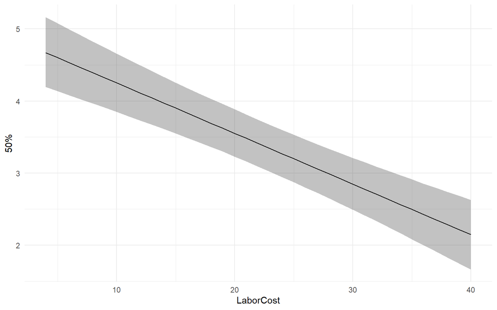

```r
#Scenario
newdata <- data.frame(
  Intercept = 1,
  OpenList = 1,
  LaborCost = seq(4,40))

#Simulate
coef.sim <- MASS::mvrnorm(
  #Number of simulations
  n = 10000,
  #Coefficients
  mu = mod2$coefficients,
  #Uncertainty/variance-covariance matrix
  Sigma = vcov(mod2)
)

#Matrix multiplication to get predicted values
preds <- coef.sim %*% t(newdata)

#Summarize the simulation
pred_summary <-
  apply(preds,
        #Apply this to columns (==2)
        MARGIN = 2,
        #What a function?
        FUN = quantile, probs = c(0.025, 0.5, 0.975))

#Add summary to data with scenarios
dfp3 <- cbind(newdata,
              t(pred_summary))



ggplot(dfp3) +
  #Plot a line this time
  geom_line(aes(
    #Predicted y-values
    y = `50%`,
    #Different scenarios
    x = LaborCost)
  ) +
    #Plot a ribbon of uncertainty
  geom_ribbon(aes(
    #Predicted y-values
    ymin = `2.5%`,
    ymax = `97.5%`,
    #Different scenarios
    x = LaborCost),
    alpha = 0.3) +
  theme_minimal()
```

# Non-linear effects

## Curvilinear

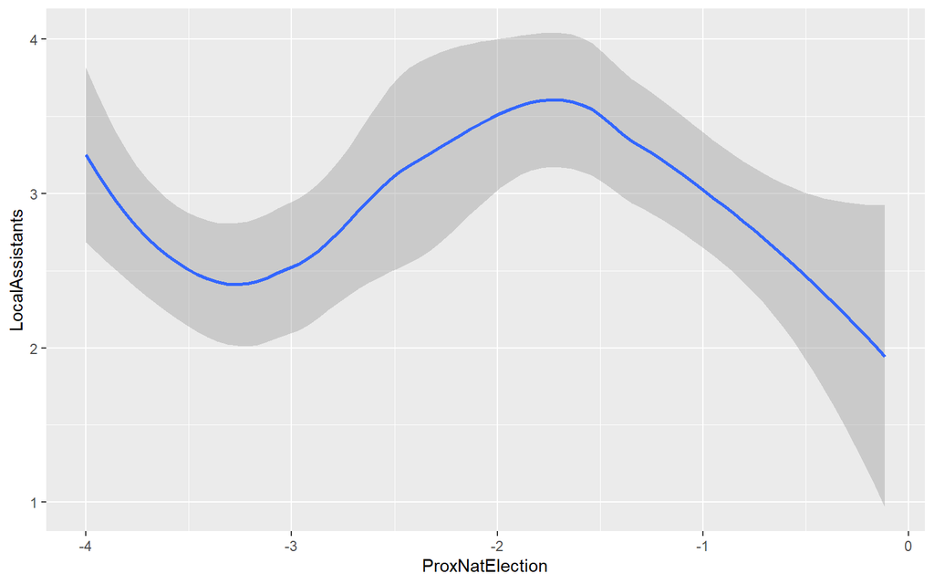

```r
ggplot(df) +
  geom_smooth(aes(x = ProxNatElection,
                  y = LocalAssistants))
```

```r
mod3 <- lm(LocalAssistants ~
             LaborCost +
             OpenList +
             ProxNatElection +
             ProxNatElection2,
           data = df)

summary(mod3)
```

```
##
## Call:
## lm(formula = LocalAssistants ~ LaborCost + OpenList + ProxNatElection +
##     ProxNatElection2, data = df)
##
## Residuals:
##    Min     1Q Median     3Q    Max
## -4.692 -1.859 -0.359  1.074 34.649
##
## Coefficients:
##                  Estimate Std. Error t value Pr(>|t|)
## (Intercept)       3.24209    0.53779   6.029 2.62e-09 ***
## LaborCost        -0.07587    0.01085  -6.993 6.06e-12 ***
## OpenList          0.92038    0.23796   3.868  0.00012 ***
## ProxNatElection  -0.81047    0.47121  -1.720  0.08586 .
## ProxNatElection2 -0.13127    0.10368  -1.266  0.20588
## ---
## Signif. codes:  0 '***' 0.001 '**' 0.01 '*' 0.05 '.' 0.1 ' ' 1
##
## Residual standard error: 3.072 on 734 degrees of freedom
## Multiple R-squared:  0.09009,    Adjusted R-squared:  0.08513
## F-statistic: 18.17 on 4 and 734 DF,  p-value: 3.053e-14
```

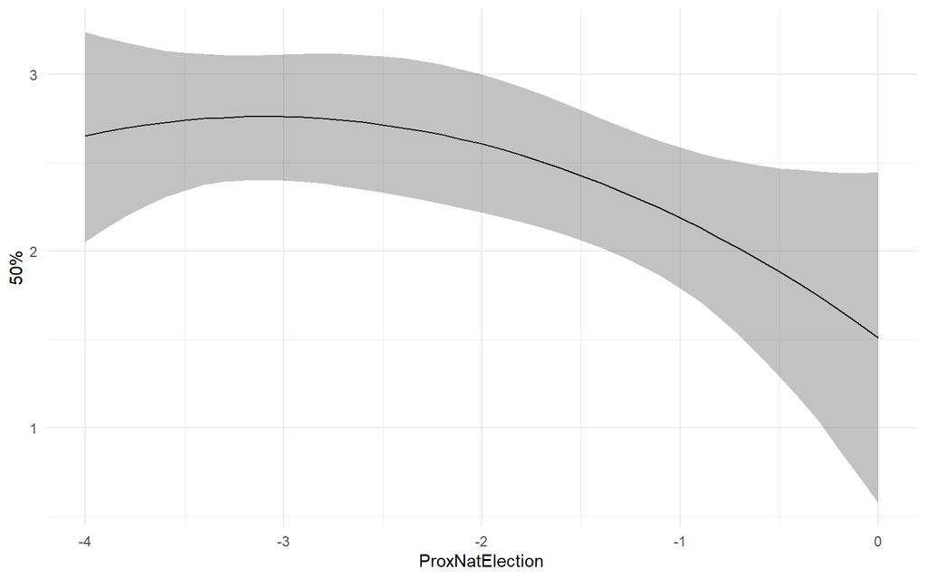

```r
#Scenario
newdata <- data.frame(
  Intercept = 1,
  LaborCost = mean(df$LaborCost),
  OpenList = 0,
  ProxNatElection = seq(from = -4, to = 0, by = 0.1),
  ProxNatElection2 = seq(from = -4, to = 0, by = 0.1)^2
  )



#Simulate
coef.sim <- MASS::mvrnorm(
  #Number of simulations
  n = 10000,
  #Coefficients
  mu = mod3$coefficients,
  #Uncertainty/variance-covariance matrix
  Sigma = vcov(mod3)
)

#Matrix multiplication to get predicted values
preds <- coef.sim %*% t(newdata)

#Summarize the simulation
pred_summary <-
  apply(preds,
        #Apply this to columns (==2)
        MARGIN = 2,
        #What a function?
        FUN = quantile, probs = c(0.025, 0.5, 0.975))

#Add summary to data with scenarios
dfp3 <- cbind(newdata,
              t(pred_summary))



ggplot(dfp3) +
  #Plot a line this time
  geom_line(aes(
    #Predicted y-values
    y = `50%`,
    #Different scenarios
    x = ProxNatElection)
  ) +
    #Plot a ribbon of uncertainty
  geom_ribbon(aes(
    #Predicted y-values
    ymin = `2.5%`,
    ymax = `97.5%`,
    #Different scenarios
    x = ProxNatElection),
    alpha = 0.3) +
  theme_minimal()
```

## Interaction

```r
mod4 <- lm(LocalAssistants ~
             LaborCost +
             OpenList +
             ProxNatElection *
             position,
           data = df)

summary(mod4)
```

```
##
## Call:
## lm(formula = LocalAssistants ~ LaborCost + OpenList + ProxNatElection *
##     position, data = df)
##
## Residuals:
##    Min     1Q Median     3Q    Max
## -4.847 -1.848 -0.561  1.052 34.723
##
## Coefficients:
##                          Estimate Std. Error t value Pr(>|t|)
## (Intercept)               6.52336    0.80885   8.065 3.47e-15 ***
## LaborCost                -0.08480    0.01148  -7.386 4.61e-13 ***
## OpenList                  0.99611    0.24027   4.146 3.83e-05 ***
## ProxNatElection           0.61116    0.31811   1.921 0.055134 .
## position                 -0.52739    0.14265  -3.697 0.000236 ***
## ProxNatElection:position -0.16618    0.06004  -2.768 0.005804 **
## ---
## Signif. codes:  0 '***' 0.001 '**' 0.01 '*' 0.05 '.' 0.1 ' ' 1
##
## Residual standard error: 3.019 on 658 degrees of freedom
##   (75 observations deleted due to missingness)
## Multiple R-squared:  0.1064, Adjusted R-squared:  0.09961
## F-statistic: 15.67 on 5 and 658 DF,  p-value: 1.372e-14
```

```r
#Check names
names(mod4$coefficients)
```

```
## [1] "(Intercept)"              "LaborCost"
## [3] "OpenList"                 "ProxNatElection"
## [5] "position"                 "ProxNatElection:position"
```

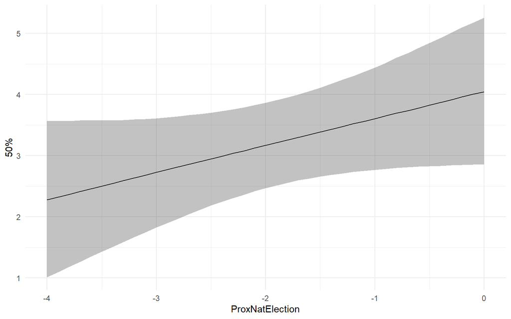

```r
#Scenario
newdata <- data.frame(
  Intercept = 1,
  LaborCost = mean(df$LaborCost),
  OpenList = 0,
  ProxNatElection = seq(from = -4, to = 0, by = 0.1),
  position = 1,
  Interaction = seq(from = -4, to = 0, by = 0.1) * 1
  )



#Simulate
coef.sim <- MASS::mvrnorm(
  #Number of simulations
  n = 10000,
  #Coefficients
  mu = mod4$coefficients,
  #Uncertainty/variance-covariance matrix
  Sigma = vcov(mod4)
)

#Matrix multiplication to get predicted values
preds <- coef.sim %*% t(newdata)

#Summarize the simulation
pred_summary <-
  apply(preds,
        #Apply this to columns (==2)
        MARGIN = 2,
        #What a function?
        FUN = quantile, probs = c(0.025, 0.5, 0.975))

#Add summary to data with scenarios
dfp4 <- cbind(newdata,
              t(pred_summary))



ggplot(dfp4) +
  #Plot a line this time
  geom_line(aes(
    #Predicted y-values
    y = `50%`,
    #Different scenarios
    x = ProxNatElection)
  ) +
    #Plot a ribbon of uncertainty
  geom_ribbon(aes(
    #Predicted y-values
    ymin = `2.5%`,
    ymax = `97.5%`,
    #Different scenarios
    x = ProxNatElection),
    alpha = 0.3) +
  theme_minimal()
```